# **The logic behind the logit**

Job talk mini-lecture

Milan Valášek

## The task

- Why logistic regression
- What it’s about
- Linear regression in fancy clothes
- Generalised linear model
- Focus on conceptual understanding

# The problem

## Recap on regression

- linear regression (AKA *linear model*) is a technique for drawing the best-fitting line through some data.
- Outcome variable is assumed to be continuous
- Model residuals should be normally distributed

## Binary data

- Sometimes, outcomes are binary
  - Pass/fail an exam
  - Get/not get a job
  - Vote for candidate A versus candidate B
- How do we model these kinds of data?

## Linear model, binary data

- $\hat{Pref} = 0.5 + 0.26\times Extraversion$

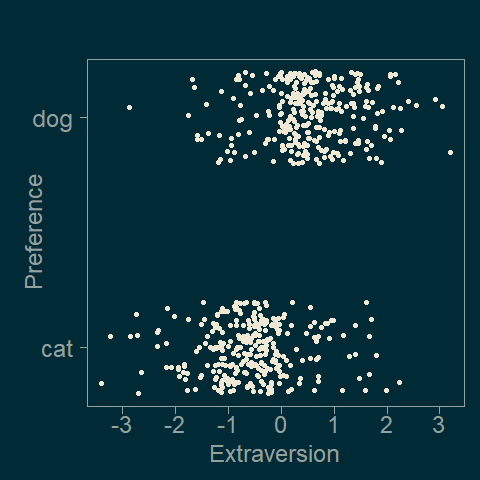

## Linear model, binary data

- $\hat{Pref} = 0.5 + 0.26\times Extraversion$

[figure not shown]

## Is it a problem?

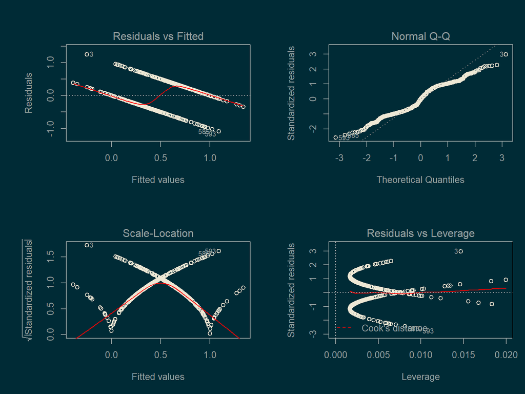

## Is it a problem?

# **Yes!**

# The solution

## Probability space

- Let’s see the proportion of prople who prefer cats at different levels of Extraversion

[figure not shown]

## Probability space

- We can fit a line through these proportions capturing the relationship

[figure not shown]

## Odds space

- Odds are similar to probabilities but:
  - Instead of dividing successed by **all posible** event, we divide by **failures**
  - The smallest possible odds are 0, just like with probability
  - Unlike probability, there is **no upper bound** to odds

## Odds space

- See what happens with our line of best fit when we redraw it in odds space

[figure not shown]

## Odds space

- See what happens with our line of best fit when we redraw it in odds space

[figure not shown]

## Log-odds space

- finally, we can take the natural logarithm of odds, stretching the plotting space even further

[figure not shown]

- finally, we can take the natural logarithm of odds, stretching the plotting space even further

[figure not shown]

## Done!

- We started with 0s and 1s – no good line to fit
- Turning 0s and 1s to *probability* revealed an *S*-shaped curve fitting the data
- Transforming the space from *probability* to *log-odds* turned the sigmoid curve into a straight line

## Done!

**Linear regression:**

$$y = b_0 + b_1X_1 + \cdots + b_nX_n + \epsilon$$

**Logistic regression:**

$$ln(ODDS(y = 1)) = b_0 + b_1X_1 + \cdots + b_nX_n + \epsilon$$

# The bigger picture

## Link function

- Logistic regression *maps the linear predictor*, $b_o + b_1X_1 + \cdots + b_nX_n$ (let’s call it $X\beta$) onto the *log-odds transformation* of the outcome variable
- The process of mapping $X\beta$ onto the outcome variable is called the **link function**
- In logistic regression, the link function is the *logit function* ($ln(\frac{P(y = 1)}{1 - P(y = 1)})$)

## Generalised linear model

- There are different link functions that can be used to *generalise* the linear model $y = X\beta + \epsilon$ to different kinds of outcome variables
- Importantly:
  - *logit function* for binomial data (logistic regression)
  - *log function* – $ln(y) = X\beta + \epsilon$ – for count data (Poisson regression)
  - *identity function* – $y = X\beta + \epsilon$ – for continuous data (linear regression)

## Logistic regression summary

- It *is* linear regression on transformed outcome
- It is used for binary outcome variable
- Link function is the logit
- Member of the generalised linear model family

## Next…

- Worked example
- Interpreting logistic regression parameters
- Model assessment
- Visualisation